# R Notebook

My hunch, from the cyanobacteria and SAR11 exemplars is that most/all ostensibly free living bacteria end up on particles in this system. Perhaps because they aggregate with paricles – that is everything sticks to everything.

How can I test whether this is the case.

Steps: * Identify bacteria that are abundant and free living (eg > 1% in the 0.2 fraction) in each sample * Quantify their abundance on the other size fractions; same sample * Identify whether each goes to zero on some size fraction. * If so, what is the mean abundance threshold where this doesn’t happen.

To do: Fix the legends so they have the same breaks and labels as everything else.

```r
library(tidyverse)
library(cowplot)
library(here)
source(here("RLibraries", "ChesapeakePersonalLibrary.R"))
# I had been bringing in all the data and just using one variable, but then I didn't.
env1 <- attach(here("RDataFiles", "InitialProcessing_3.RData"))
#load(here("RDataFiles", "nonSpikes.RData"))
set.seed(10033)
nonSpikes <- env1$nonSpikes
nonSpikes <- nonSpikes %>% mutate(fStation = factor(Station, levels = as.character(c(3.1, 3.2, 3.3, 5.1, 4.3, 5.5))))
my_stations <- nonSpikes$Station %>% unique()
## somewhat to my suprise, variables such as taxa01 appear to be globally available even though they should be only in env1
# I'm going to leave things like this since code runs and I'm running out of steam on this code wrangling
```

```r
onePercenters <- nonSpikes %>%
  select(ID, Station, Size_Class, Depth, ASV, RA) %>%
  # filter(Station %in% c(3.1, 3.2, 4.3)) %>%
  # filter(Depth == "Surface") %>%
  filter(Size_Class == 0.2, RA > 0.01) %>%
  pull(ASV) %>% unique()

onePercenters_Surface <- nonSpikes %>%
  select(ID, Station, Size_Class, Depth, ASV, RA) %>%
  filter(Station %in% c(3.1, 3.2, 4.3)) %>%
  filter(Depth == "Surface") %>%
  filter(Size_Class == 0.2, RA > 0.01) %>%
  pull(ASV) %>% unique()

onePercenters_Oxycline <- nonSpikes %>%
  select(ID, Station, Size_Class, Depth, ASV, RA) %>%
  #filter(Station %in% c(3.1, 3.2, 4.3)) %>%
  filter(Depth == "Oxycline") %>%
  filter(Size_Class == 0.2, RA > 0.01) %>%
  pull(ASV) %>% unique()

onePercenters_Bottom <- nonSpikes %>%
  select(ID, Station, Size_Class, Depth, ASV, RA) %>%
  #filter(Station %in% c(3.1, 3.2, 4.3)) %>%
  filter(Depth == "Bottom") %>%
  filter(Size_Class == 0.2, RA > 0.01) %>%
  pull(ASV) %>% unique()

onePercenters
```

```
 [1] "ASV_2"   "ASV_3"   "ASV_4"   "ASV_8"   "ASV_13"  "ASV_27"  "ASV_28"  "ASV_32"  "ASV_33"  "ASV_41"  "ASV_43"  "ASV_50"  "ASV_61"  "ASV_63"
[15] "ASV_68"  "ASV_75"  "ASV_77"  "ASV_88"  "ASV_96"  "ASV_98"  "ASV_100" "ASV_104" "ASV_107" "ASV_111" "ASV_120" "ASV_144" "ASV_146" "ASV_157"
[29] "ASV_159" "ASV_161" "ASV_169" "ASV_171" "ASV_182" "ASV_191" "ASV_200" "ASV_211" "ASV_227" "ASV_244" "ASV_298" "ASV_314" "ASV_329" "ASV_375"
[43] "ASV_378"
```

```r
onePercenters_Surface
```

```
 [1] "ASV_3"   "ASV_4"   "ASV_8"   "ASV_27"  "ASV_32"  "ASV_41"  "ASV_43"  "ASV_61"  "ASV_63"  "ASV_100" "ASV_104" "ASV_107" "ASV_111" "ASV_146"
[15] "ASV_157" "ASV_159" "ASV_169" "ASV_171" "ASV_182" "ASV_200" "ASV_298"
```

```r
onePercenters_Bottom
```

```
 [1] "ASV_3"   "ASV_4"   "ASV_8"   "ASV_13"  "ASV_27"  "ASV_28"  "ASV_32"  "ASV_33"  "ASV_41"  "ASV_50"  "ASV_61"  "ASV_63"  "ASV_68"  "ASV_75"
[15] "ASV_77"  "ASV_88"  "ASV_96"  "ASV_98"  "ASV_100" "ASV_104" "ASV_107" "ASV_111" "ASV_120" "ASV_144" "ASV_146" "ASV_161" "ASV_191" "ASV_200"
[29] "ASV_211" "ASV_227" "ASV_244" "ASV_314" "ASV_329" "ASV_375" "ASV_378"
```

Lets look at their taxonomy

```r
onePercentFreeTaxa <- taxa01 %>% filter(ASV %in% onePercenters)
```

```r
nonSpikes1pct <- nonSpikes %>% filter(ASV %in% onePercenters)
nonSpikes1pct_Surface <- nonSpikes %>% filter(ASV %in% onePercenters_Surface) # Includes all depths
nonSpikes1pct_Oxycline <- nonSpikes %>% filter(ASV %in% onePercenters_Oxycline)
nonSpikes1pct_Bottom <- nonSpikes %>% filter(ASV %in% onePercenters_Bottom)
```

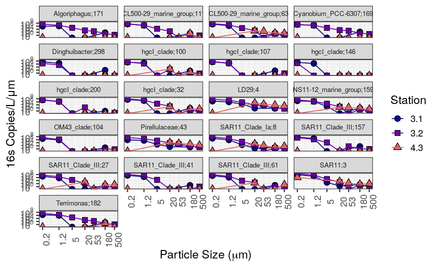

```r
surfaceNSPlot <- nonSpikes1pct_Surface %>%

  filter(Station %in% c(3.1, 3.2, 4.3)) %>%
  filter(Depth == "Surface") %>%
  arrange(Size_Class) %>%
  ggplot(aes(y = copiesPerL/Bin_Size, x = Size_Class, fill = fStation, shape = fStation)) +
  scale_y_log10nice(omag = seq(-10, 20, by = 2)) + scale_x_log10(breaks = my_sizes, labels = as.character(my_sizes)) +
  facet_wrap(~Tag_ASV, ncol = 4) +
  geom_point(size = 3) +
  geom_path(aes(color = as.factor(fStation))) +

  ## Manually specify the shapes and colors to match the other plot
  scale_shape_manual(values = rep(21:25, 2)[c(1,2,4)]) +
  scale_fill_manual(values = viridis::plasma(n = 6)[c(1,2,4)]) +
  scale_color_manual(values = viridis::plasma(n = 6)[c(1,2,4)]) +
  theme_bw(base_size = 14) +
  #theme(axis.text.x = element_text(angle = 90), legend.position = "none") +
  labs(y = "16s Copies/L/μm", x = expression(paste("Particle Size (", mu, "m)")), fill = "Station", color = "Station", shape = "Station")  +
  theme(axis.text.x = element_text(angle = 90), strip.text = element_text(size = 8))
surfaceNSPlot
ggsave(here("Figures", "surfaceNS.png"), plot = surfaceNSPlot, height = 8, width = 8.5, limitsize = FALSE)
```

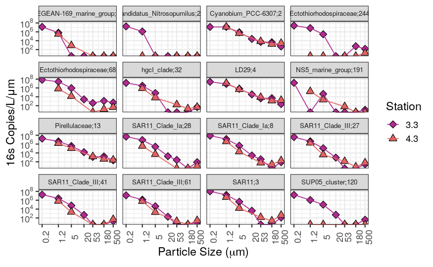

```r
oxyclineNSPlot <- nonSpikes1pct_Oxycline %>%

  filter(Station %in% c(3.3, 4.3)) %>%
  filter(Depth == "Oxycline") %>%
  arrange(Size_Class) %>%
  ggplot(aes(y = copiesPerL/Bin_Size, x = Size_Class, fill = fStation, shape = fStation)) +
  scale_y_log10nice(omag = seq(-10, 20, by = 2)) + scale_x_log10(breaks = my_sizes, labels = as.character(my_sizes)) +
  facet_wrap(~Tag_ASV, ncol = 4) +
  geom_point(size = 3) +
  geom_path(aes(color = as.factor(fStation))) +

  ## Manually specify the shapes and colors to match the other plot
  scale_shape_manual(values = rep(21:25, 2)[c(3,4)]) +
  scale_fill_manual(values = viridis::plasma(n = 6)[c(3,4)]) +
  scale_color_manual(values = viridis::plasma(n = 6)[c(3,4)]) +
  theme_bw(base_size = 14) +
  #theme(axis.text.x = element_text(angle = 90), legend.position = "none") +
  labs(y = "16s Copies/L/μm", x = expression(paste("Particle Size (", mu, "m)")), fill = "Station", color = "Station", shape = "Station")  +
  theme(axis.text.x = element_text(angle = 90), strip.text = element_text(size = 8))
oxyclineNSPlot
ggsave(here("Figures", "oxyclineNS.png"), plot = oxyclineNSPlot, height = 8, width = 8.5, limitsize = FALSE)
```

[figure not shown]

```r
bottomNSPlot <- nonSpikes1pct_Bottom %>% filter(Depth == "Bottom") %>%
  arrange(Size_Class) %>%
  ggplot(aes(y = copiesPerL/Bin_Size, x = Size_Class, fill = as.factor(Station), shape = as.factor(Station))) +
  scale_y_log10nice(omag = seq(-10, 20, by = 2)) + scale_x_log10(breaks = my_sizes, labels = as.character(my_sizes)) +
  facet_wrap(~Tag_ASV, ncol = 4) +
  geom_point(size = 3) +
  geom_path(aes(color = as.factor(Station))) +
 ## Manually specify the shapes and colors to match the other plot
  scale_shape_manual(values = rep(21:25, 2)[-3]) +
  scale_fill_manual(values = viridis::plasma(n = 6)[-3]) +
  scale_color_manual(values = viridis::plasma(n = 6)[-3]) +
  theme_bw(base_size = 12) +
  #theme(axis.text.x = element_text(angle = 90), legend.position = "none") +
  labs(y = "16s Copies/L/μm", x = expression(paste("Particle Size (", mu, "m)")), fill = "Station", color = "Station", shape = "Station") +
  theme(axis.text.x = element_text(angle = 90), strip.text = element_text(size = 8))
bottomNSPlot
```

```r
ggsave(here("Figures", "bottomNS.png"), plot = bottomNSPlot, height = 11, width = 8.5, limitsize = FALSE)
```

SAR11 surface III clade

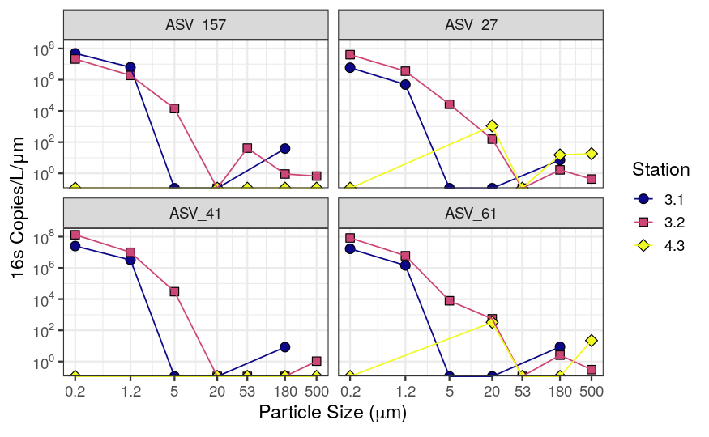

```r
nonSpikes1pct %>% filter(Depth == "Surface") %>%
  #filter(ASV == "ASV_2") %>%
  filter(Tag == "SAR11_Clade_III") %>%
  filter(Station %in% c(3.1, 3.2, 4.3)) %>%
  arrange(Size_Class) %>%
  ggplot(aes(y = copiesPerL/Bin_Size, x = Size_Class, fill = as.factor(Station), shape = as.factor(Station))) +
  scale_y_log10nice(omag = seq(-10, 20, by = 2)) + scale_x_log10(breaks = my_sizes, labels = as.character(my_sizes)) +
  facet_wrap(~ASV) +
  geom_point(size = 3) +
  geom_path(aes(color = as.factor(Station))) +
  scale_shape_manual(values = rep(21:25, 2)) +
  scale_fill_viridis_d(option = "plasma") +
  scale_color_viridis_d(option = "plasma") +
  theme_bw(base_size = 14) +
  #theme(axis.text.x = element_text(angle = 90), legend.position = "none") +
  labs(y = "16s Copies/L/μm", x = expression(paste("Particle Size (", mu, "m)")), fill = "Station", color = "Station", shape = "Station")
```

```r
nonSpikes1pct %>% filter(Depth == "Surface") %>%
  filter(ASV == "ASV_3") %>%
  #filter(Tag == "SAR11_Clade_III") %>%
  filter(Station %in% c(3.1)) %>%
  arrange(Size_Class)
```

| ASV | reads | ID | Kingdom | Phylum | Class | Order | Family | Genus | nASV | TagLevel | Tag | Tag_ASV | Station | Size_Class | Depth | Bin_Size | DNAperLiter | MassperLiter | ParticlesPerLiter | Flag | δ13CVPDB (‰) | δ15NAir (‰) | CarbonPerLiter_mg | NitrogenPerLiter_mg | Depth_m | Temperature | Salinity | Oxygen | Fluorescence | … |
| --- | --- | --- | --- | --- | --- | --- | --- | --- | --- | --- | --- | --- | --- | --- | --- | --- | --- | --- | --- | --- | --- | --- | --- | --- | --- | --- | --- | --- | --- | --- |
| ASV_3 | 2065 | 3-1-S-0-2 | Bacteria | α-proteobacteria | α-proteobacteria | SAR11 | NA | NA | 3 | Order | SAR11 | SAR11;3 | 3.1 | 0.2 | Surface | 1.0 | 3690.4761905 | NA | NA | FALSE | NA | NA | NA | NA | 3 | 28.8871 | 1.30942 | 3.904549 | 1.988037 | … |
| ASV_3 | 596 | 3-1-S-1-2 | Bacteria | α-proteobacteria | α-proteobacteria | SAR11 | NA | NA | 3 | Order | SAR11 | SAR11;3 | 3.1 | 1.2 | Surface | 3.8 | 3478.7234043 | 6.34000000 | 2665036541 | FALSE | -28.36021 | 10.02959 | 1.15736939 | 0.155890397 | 3 | 28.8871 | 1.30942 | 3.904549 | 1.988037 | … |
| ASV_3 | 20 | 3-1-S-5 | Bacteria | α-proteobacteria | α-proteobacteria | SAR11 | NA | NA | 3 | Order | SAR11 | SAR11;3 | 3.1 | 5.0 | Surface | 15.0 | 15.1283422 | 2.97187879 | 76085337 | FALSE | -27.21983 | 17.12789 | 0.86637761 | 0.054890962 | 3 | 28.8871 | 1.30942 | 3.904549 | 1.988037 | … |
| ASV_3 | 43 | 3-1-S-20 | Bacteria | α-proteobacteria | α-proteobacteria | SAR11 | NA | NA | 3 | Order | SAR11 | SAR11;3 | 3.1 | 20.0 | Surface | 33.0 | 0.7870312 | 0.56084063 | 1393952 | FALSE | -26.55731 | 22.01444 | 0.07948501 | 0.009439897 | 3 | 28.8871 | 1.30942 | 3.904549 | 1.988037 | … |
| ASV_3 | 60 | 3-1-S-180 | Bacteria | α-proteobacteria | α-proteobacteria | SAR11 | NA | NA | 3 | Order | SAR11 | SAR11;3 | 3.1 | 180.0 | Surface | 320.0 | 30.4415584 | 0.06857143 | 6839 | FALSE | -28.77966 | 15.25442 | 0.01278491 | 0.001236975 | 3 | 28.8871 | 1.30942 | 3.904549 | 1.988037 | … |

Ok, there are bacteria that are not on *some* size fractions of particles. What about ones that are on 0.2 but not 1.2?

```r
check12 <- nonSpikes %>%
  select(Station, Size_Class, Depth, ASV, RA) %>%
  filter(Size_Class %in% c(0.2, 1.2)) %>%
  pivot_wider(names_from = Size_Class, values_from = RA) %>%
  filter(!is.na(`0.2`) & !is.na(`1.2`)) %>%
  #filter(`0.2` > .03, `1.2` == 0) # never happens at 3%, happens 4 times at 1%
  identity()
check12
```

| Station | Depth | ASV | 0.2 | 1.2 |
| --- | --- | --- | --- | --- |
| 3.1 | Bottom | ASV_2 | 2.609735e-03 | 2.571452e-02 |
| 3.1 | Surface | ASV_2 | 9.800719e-04 | 1.009671e-02 |
| 3.2 | Bottom | ASV_2 | 3.203113e-03 | 3.686332e-02 |
| 3.2 | Surface | ASV_2 | 2.449701e-03 | 4.886048e-02 |
| 3.3 | Oxycline | ASV_2 | 1.051459e-02 | 2.084090e-02 |
| 4.3 | Bottom | ASV_2 | 3.368682e-03 | 1.255043e-02 |
| 5.1 | Bottom | ASV_2 | 3.443572e-03 | 1.604188e-02 |
| 3.1 | Bottom | ASV_3 | 6.510868e-02 | 3.656814e-02 |
| 3.1 | Surface | ASV_3 | 5.621801e-02 | 1.690349e-02 |
| 3.2 | Bottom | ASV_3 | 8.634169e-02 | 8.992305e-02 |

[output cut: 990 more lines]